# **Practice reports**

## **Report for month July of 2019 and for the following GP: A81005**

This report is generated using information on a **sample** of drugs prescriptions in primary care in *England* for the month July 2019.

You can change *month*, *year* and *Practice* name (gp) of the present report, by changing the values of the corresponding `params` in the **YAML** section.

If you don’t know which GP to chise, pick up one in following list showing a sample of 100 GPs included in the data-sample:

```
##   [1] "Y03645" "N81107" "N81052" "A81046" "P82030" "N81049" "A83036" "N85019" "A81065" "N85038"
##  [11] "A83019" "Y00048" "Y05773" "N85643" "Y05749" "N81060" "N81032" "P82004" "N81042" "Y05476"
##  [21] "N81068" "A81032" "N85027" "A83637" "A83642" "N85005" "Y05872" "Y06484" "N81048" "A81034"
##  [31] "Y03078" "A81058" "A83627" "N85006" "Y03929" "A81631" "Y04925" "N81108" "A83035" "N85629"
##  [41] "P82031" "Y05785" "N81122" "N81614" "N81089" "N81074" "N81061" "N85009" "Y05862" "Y04109"
##  [51] "N81014" "A83013" "A81611" "N85052" "A81014" "Y04664" "Y06486" "A81044" "A83023" "A81022"
##  [61] "Y00434" "N85012" "N81071" "N81044" "N85057" "P82011" "A83004" "Y03089" "N81016" "Y00327"
##  [71] "A81048" "A81632" "A83046" "Y06115" "N85014" "Y03058" "P82029" "Y05735" "A81052" "A81001"
##  [81] "Y02083" "A81051" "N81114" "N85034" "Y02162" "A83030" "N81088" "A83009" "Y03953" "A83003"
##  [91] "Y01706" "A83071" "A81621" "Y06116" "N85013" "Y05781" "A81009" "Y05791" "N81038" "P82016"
```

## Summary stats

The practice presents the following values:

- 16868 prescribed items
- 114288.36 Net Ingredient Costs (NIC)

## Cost Distribution

We check how the practice performs in terms of costs compared to all other practices.

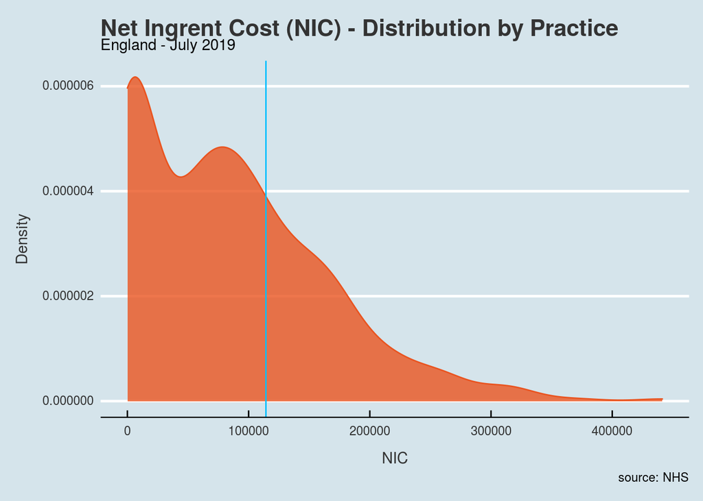

The figure above shows the value of the selected practice (in light blue).

The practice A81005 has a NIC which is in the top 69 of the NIC distribution.

## Prescription rates

We now report the prescription rate for the selected practice.

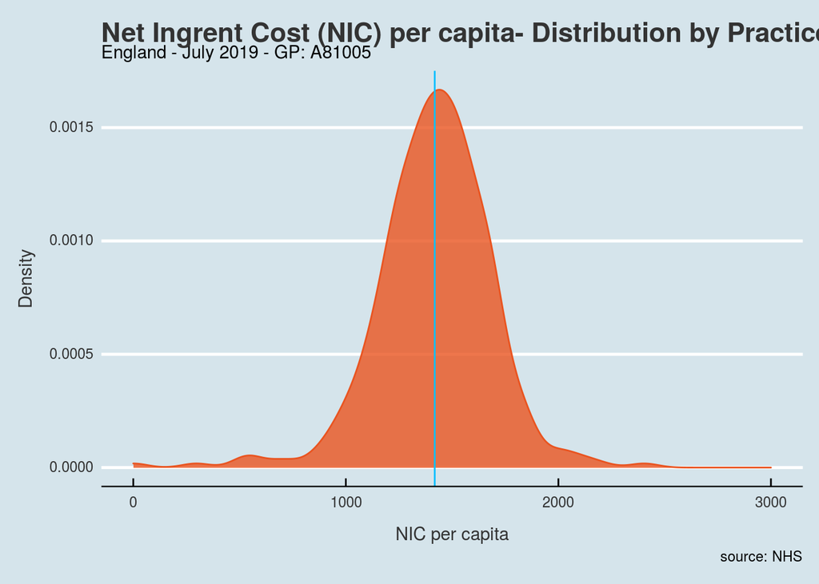

The figure above shows the value of the Net Ingredient Costs (NIC) per capita of the selected practice (in light blue).

The practice A81005 has a NIC which is in the top 47 of the NIC distribution.

## Highly prescribing practices

The practice **is not** one of the top prescribing practices.